# Parametric Tests

Pongsun B.

2026-01-14

## ==== Introduction to Parametric Tests ====

Parametric statistical tests are among the most common you’ll encounter. They include *t*-test, analysis of variance, and linear regression.

They are used when the dependent variable is an **interval/ratio** data variable. This might include variables measured in science such as fish length, child height, crop yield weight, or pollutant concentration in water.

One advantage of using parametric statistical tests is that your audience will likely be familiar with the techniques and interpretation of the results. These tests are also often more flexible and more powerful than their nonparametric analogues.

Their major drawback is that all parametric tests assume something about the distribution of the underlying data. If these assumptions are violated, the resultant test statistics will not be valid, and the tests will not be as powerful as for cases when assumptions are met.

#### **Count data may not be appropriate for common parametric tests**

A frequent error is to use common parametric models and tests with count data for the dependent variable. Instead, count data could be analyzed either by using tests for nominal data or by using regression methods appropriate for count data. These include Poisson regression, negative binomial regression, and zero-inflated Poisson regression.

#### **Percentage and proportion data**

Percentage and proportion data are often inappropriate for parametric statistics for the same reasons given for count data. They will often not meet the assumptions of the tests, and are particularly problematic if there are some or many observations close to 0 or 1. The arcsine transformation was used traditionally, but logistic regression or beta regression may be more appropriate. However, if assumptions are approximately met, parametric analyses could be used.

### **Assumptions in parametric statistics**

All parametric analyses have assumptions about the underlying data, and these assumptions should be confirmed or assumed with good reason when using these tests.

1. **Random sampling**

   All statistical tests assume that the data captured in the sample are randomly chosen from the population as a whole. Selection bias will obviously affect the validity of the outcome of the analysis.
2. **Normal distribution of data**

   Parametric tests assume that the data come from a population of known distribution. In particular, the tests discussed in this class assume that the distribution of the data are normal in distribution. This will usually be assessed with a histogram of residuals, a density plot, or quantile–quantile (normal probability) plot.
3. **Homogeneity of variance**

   Parametric analyses will also assume a homogeneity of variance among groups. That is, for Student’s *t*-test comparing two groups, each group should have the same variance. As a technical note, by default R conducts a variant of the *t*-test called Welch’s *t*-test. This test does not assume homogeneity of variance and so can be used to compare two groups with unequal variances.
4. **Outliers**

   Outliers are observations whose value is far outside what is expected. They can play havoc with parametric analyses since they affect the distribution of the data and strongly influence the mean. There are a variety of formal tests for detecting outliers, but they will not be discussed here. It’s my opinion that outliers should not be removed from data unless there is a good reason, usually when a value is impossible or a measurement error of some kind is suspected.

## ==== **One-sample t-test** ====

One-sample tests are not used too often, but are useful to compare a set of values to a given default value. For example, one might ask if a set of student scores are significantly different from a “default” or “neutral” score of 75.

**Appropriate data**

- One-sample data.
- Data are **interval/ratio**, and are continuous.
- Data are normally distributed.
- Moderate skewness is permissible if the data distribution is unimodal without outliers.

**Hypotheses**

- Null hypothesis: The mean of the population from which the data were sampled is equal to the default value.
- Alternative hypothesis (two-sided): The mean of the population from which the data were sampled is not equal to the default value.

**Interpretation**

Reporting significant results as, e.g., “Mean score for Variable A was significantly different from a default value of 75” is acceptable.

### **One-sample *t*-test example**

In the following example, Brendon Small has his students keep diaries of what they eat for a week, and then calculate the daily sodium intake in milligrams. As a first step in the analysis, he wants to compare mean sodium intake by his students to the American Heart Association recommendation of 1500 mg.

A one-sample *t*-test can be conducted with the `t.test` function in the native `stats` package. Conveniently the output includes the mean of the sample, a confidence interval for that mean, and a *p*-value for the *t*-test.

`t.test(x, y = NULL,`

`alternative = c("two.sided", "less", "greater"),`

`mu = 0, paired = FALSE, var.equal = FALSE,`

`conf.level = 0.95, …)`

**Test of Normality**

- Histogram
- Normal quantile plot

```r
MyData <- read_xlsx("./Data/parametric_data.xlsx", sheet = "Sheet1", range = "A1:C21")

# Check the data frame
str(MyData)
```

```
## tibble [20 × 3] (S3: tbl_df/tbl/data.frame)
##  $ Instructor: chr [1:20] "Brendon Small" "Brendon Small" "Brendon Small" "Brendon Small" ...
##  $ Student   : chr [1:20] "a" "b" "c" "d" ...
##  $ Sodium    : num [1:20] 1200 1400 1350 950 1400 ...
```

```r
summary(MyData)
```

```
##   Instructor          Student              Sodium
##  Length:20          Length:20          Min.   : 950
##  Class :character   Class :character   1st Qu.:1150
##  Mode  :character   Mode  :character   Median :1300
##                                        Mean   :1288
##                                        3rd Qu.:1400
##                                        Max.   :1700
```

```r
sd(MyData$Sodium)
```

```
## [1] 193.7341
```

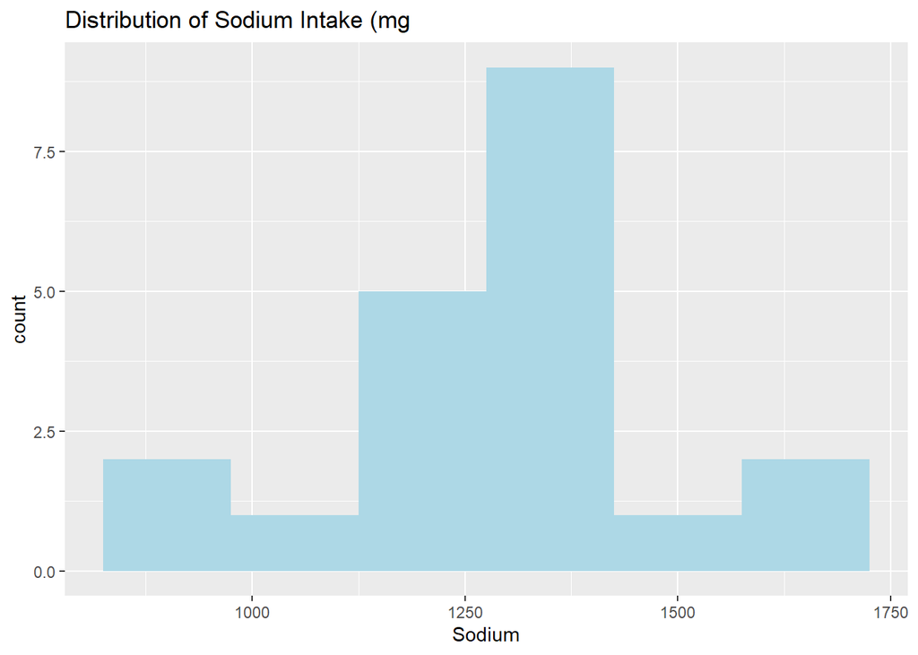

```r
## Test of Normality Histogram of MyData$Sodium
ggplot(MyData, aes(x = Sodium)) + geom_histogram(bins = 6, fill = "lightblue") +
    ggtitle("Distribution of Sodium Intake (mg")
```

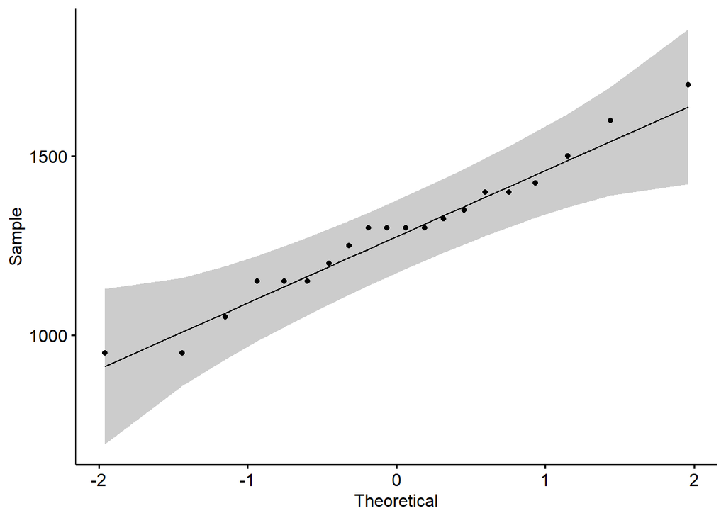

```r
# Normal quantile plot
library(ggpubr)
ggqqplot(MyData$Sodium)
```

```r
# Shapiro–Wilk normality test
shapiro.test(MyData$Sodium)
```

```
##
##  Shapiro-Wilk normality test
##
## data:  MyData$Sodium
## W = 0.97212, p-value = 0.7989
```

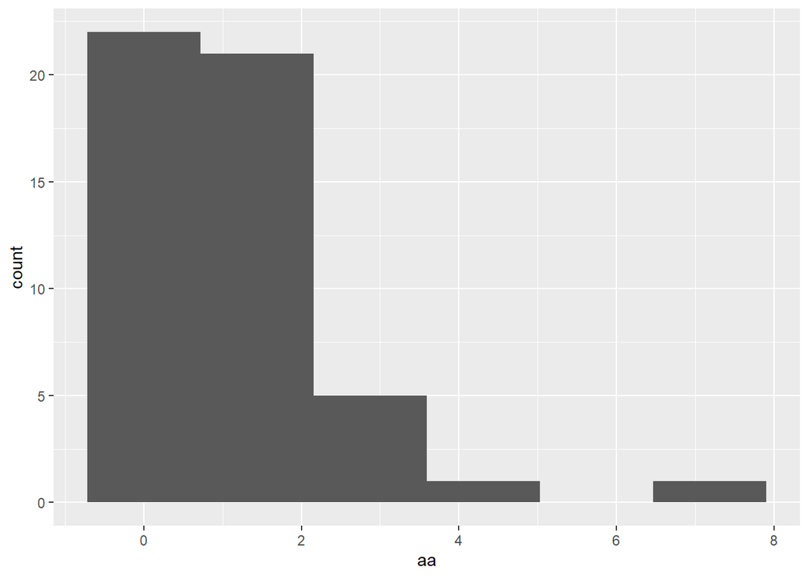

```r
# H0 Data is normal == yes H1 Data is not normal if p-value is more than apha
# == fail to reject H0, eg alpha == 0.05

# Example of non-normality
set.seed(123)
aa <- rexp(50)
ggplot(NULL, aes(aa)) + geom_histogram(bins = 6)
```

```r
aa
```

```
##  [1] 0.84345726 0.57661027 1.32905487 0.03157736 0.05621098 0.31650122
##  [7] 0.31422729 0.14526680 2.72623646 0.02915345 1.00483006 0.48021473
## [13] 0.28101363 0.37711783 0.18828404 0.84978613 1.56320354 0.47876042
## [19] 0.59093484 4.04101171 0.84314973 0.96587121 1.48527579 1.34804449
## [25] 1.16852898 1.60585234 1.49674287 1.57065255 0.03176774 0.59784969
## [31] 2.16783975 0.50661573 0.25955782 2.59689212 1.22902573 0.79068176
## [37] 0.62928008 1.25464100 0.58868464 1.12929003 0.42036480 7.21100758
## [43] 0.84572197 0.22554201 1.10033882 2.24830569 1.36373430 0.57639167
## [49] 2.72527585 1.31216304
```

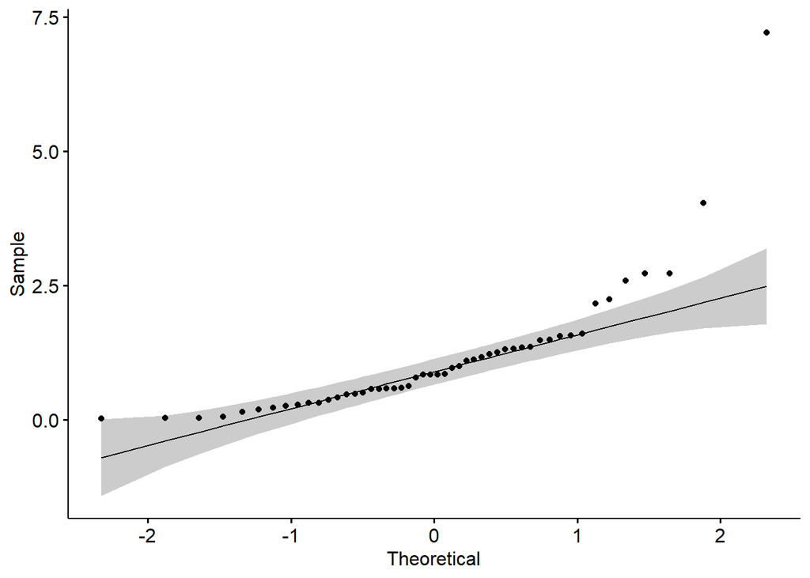

```r
# Normal quantile plot
ggqqplot(aa)
```

```r
# Shapiro–Wilk normality test
shapiro.test(aa)
```

```
##
##  Shapiro-Wilk normality test
##
## data:  aa
## W = 0.71275, p-value = 1.412e-08
```

```r
## One-sample t-test H0: mu >= 1500 H1: mu < 1500 greater: > , less: < ; alpha
## == 0.1; fail to reject H0; so students does not intake more than 1500 mg;

t.test(MyData$Sodium, mu = 1500, alternative = "greater", conf.level = 0.9)
```

```
##
##  One Sample t-test
##
## data:  MyData$Sodium
## t = -4.9053, df = 19, p-value = 1
## alternative hypothesis: true mean is greater than 1500
## 90 percent confidence interval:
##  1229.982      Inf
## sample estimates:
## mean of x
##    1287.5
```

```r
# Conclusion


# How to calculate the test statistic manually
```

## ==== **Two-sample t-test** ====

The two-sample unpaired *t*-test is a commonly used test that compares the means of two samples.

**Appropriate data**

- Two-sample data. That is, one measurement variable in two groups or samples.
- Dependent variable is **interval/ratio**, and is continuous.
- Independent variable is a factor with two levels. That is two groups.
- Data for each population are normally distributed.
- For Student’s *t*-test, the two samples need to have the same variance. However, Welch’s *t*-test, which is used by default in R, does not assume equal variances.
- Observations between groups are independent. That is, not paired or repeated measures data.
- Moderate skewness is permissible if the data distribution is uni-modal without outliers.

**Hypotheses**

- Null hypothesis: The means of the populations from which the data were sampled for each group are equal.
- Alternative hypothesis (two-sided): The means of the populations from which the data were sampled for each group are not equal.

**Interpretation**

Reporting significant results as “Mean of variable Y for group A was different than that for group B.” is acceptable.

### **Two-sample *t*-test example**

In the following example, Brendon Small and Coach McGuirk have their SNAP-Ed students keep diaries of what they eat for a week, and then calculate the daily sodium intake in milligrams. Since the classes have received different nutrition education programs, they want to see if the mean sodium intake is the same for both classes.

A two-sample *t*-test can be conducted with the `t.test` function. The default is to use Welch’s t-test, which doesn’t require equal variance between groups. Conveniently the output includes the mean of each sample, a confidence interval for the difference in means, and a *p*-value for the *t*-test.

```r
MyData2 <- read_xlsx("./Data/parametric_data.xlsx",
                     sheet = "Sheet2",
                     range = "A1:D41");

# group_by and summarise ต้องใช้คู่กัน

# ctrl + shift + M or |>

MyData2 %>%
  group_by(Instructor) %>%
  summarise(mean = mean(Sodium),
            sd = sd(Sodium),
            max = max(Sodium),
            min = min(Sodium))
```

```
## # A tibble: 2 × 5
##   Instructor     mean    sd   max   min
##   <chr>         <dbl> <dbl> <dbl> <dbl>
## 1 Brendon Small 1288.  194.  1700   950
## 2 Coach McGuirk 1246.  142.  1525  1000
```

```r
# new pipe
MyData2 |> group_by(Instructor) |> summarise(mean = mean(Sodium),
                                            sd = sd(Sodium),
                                            max = max(Sodium),
                                            min = min(Sodium))
```

```
## # A tibble: 2 × 5
##   Instructor     mean    sd   max   min
##   <chr>         <dbl> <dbl> <dbl> <dbl>
## 1 Brendon Small 1288.  194.  1700   950
## 2 Coach McGuirk 1246.  142.  1525  1000
```

```r
# Summarize data by group
library(FSA) # ~ Tilde : x ~ y means x is a function of y;
Summarize(Sodium ~ Instructor + Color,
          data = MyData2,
          digits = 3)
```

```
##      Instructor  Color  n   mean      sd  min      Q1 median      Q3  max
## 1 Brendon Small    Red 10 1300.0 161.159  950 1225.00 1337.5 1400.00 1500
## 2 Coach McGuirk    Red 10 1260.0 136.524 1050 1200.00 1250.0 1343.75 1525
## 3 Brendon Small Yellow 10 1275.0 230.036  950 1150.00 1275.0 1300.00 1700
## 4 Coach McGuirk Yellow 10 1232.5 154.133 1000 1131.25 1200.0 1356.25 1500
```

```r
# F-test to test for homogeneity in variances
# ทดสอบว่า varience ใกล้เคียงกันมั้ย
# H0: ratio of variances is equal to 1
# H1: ratio of variances is not equal to 1
var.test(Sodium ~ Instructor,
         data = MyData2,
         digits = 3);
```

```
##
##  F test to compare two variances
##
## data:  Sodium by Instructor
## F = 1.8506, num df = 19, denom df = 19, p-value = 0.1889
## alternative hypothesis: true ratio of variances is not equal to 1
## 95 percent confidence interval:
##  0.7324981 4.6755016
## sample estimates:
## ratio of variances
##            1.85062
```

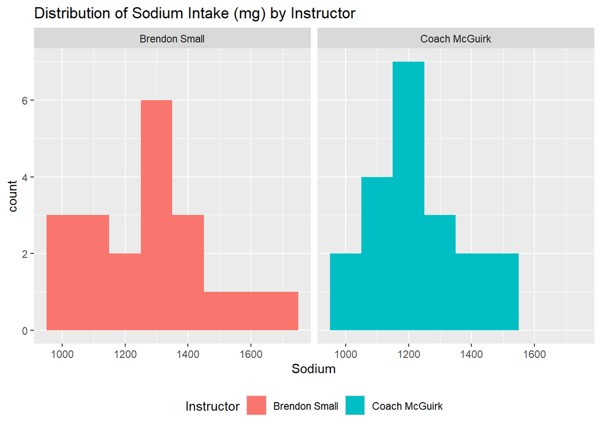

```r
# Result shown that p-value > alpha ,so H0 is true then varience is equally --> student t-test.

## Test of Normality
# Histograms of each group

ggplot(MyData2, aes(x = Sodium, group = Instructor,fill = Instructor)) +
  geom_histogram(binwidth= 100) +
  facet_grid(~ Instructor) + #ด้าน or facet_grid(Instructor ~ .)
  theme(legend.position = "bottom") +
  ggtitle("Distribution of Sodium Intake (mg) by Instructor");
```

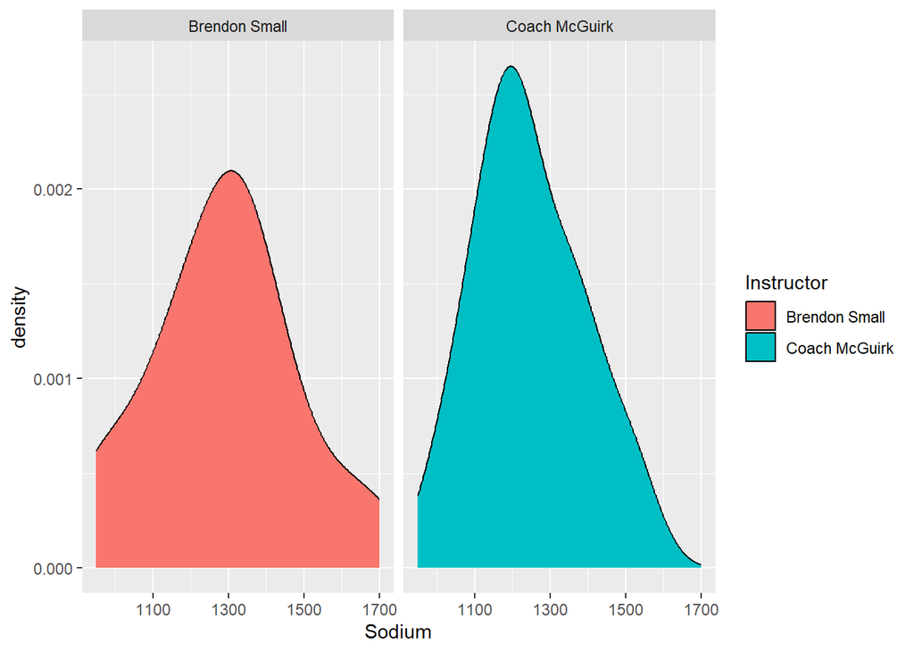

```r
# Density plot
ggplot(MyData2, aes(x = Sodium, group = Instructor,fill = Instructor)) +
  geom_density() +
  facet_grid((~ Instructor))
```

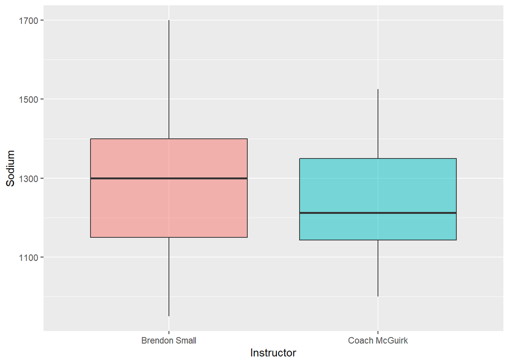

```r
# Box plots by group
ggplot(MyData2, aes(y = Sodium, x = Instructor, group = Instructor,fill = Instructor)) +
  geom_boxplot(alpha = 0.5) + # alpha == transparent
  theme(legend.position = "null");
```

```r
# Shapiro–Wilk normality test
MyData2_wide <- pivot_wider(MyData2,
                            names_from = "Instructor",
                            values_from = "Sodium")

shapiro.test(MyData2_wide$`Brendon Small`)
```

```
##
##  Shapiro-Wilk normality test
##
## data:  MyData2_wide$`Brendon Small`
## W = 0.97212, p-value = 0.7989
```

```r
shapiro.test(MyData2_wide$`Coach McGuirk`)
```

```
##
##  Shapiro-Wilk normality test
##
## data:  MyData2_wide$`Coach McGuirk`
## W = 0.96772, p-value = 0.7062
```

```r
#conclusion Brendon is normal dist and Coach is normal dist;
#p-value is more than 0.05 , so fail to reject H0;

## Two-sample unpaired t-test
# H0: mu1 (Brendon) <= mu2 (Coach)
# H1: mu1 (Brendon) > mu2 (Coach)
t.test(Sodium ~ Instructor,
       data = MyData2,
       alternative = "two.sided",
       var.equal = T);
```

```
##
##  Two Sample t-test
##
## data:  Sodium by Instructor
## t = 0.76722, df = 38, p-value = 0.4477
## alternative hypothesis: true difference in means between group Brendon Small and group Coach McGuirk is not equal to 0
## 95 percent confidence interval:
##  -67.59215 150.09215
## sample estimates:
## mean in group Brendon Small mean in group Coach McGuirk
##                     1287.50                     1246.25
```

```r
# t.test default is wrench t-test

# Conclusion
# Fail to reject H0, so mu(coach) ~= mu(brandon)

# H1: mu2 (Coach) < mu1 (Brendon)
# H0 mu1 = mu2;
# brendon first
t.test(Sodium ~ Instructor,
       data = MyData2,
       alternative = "greater",
       var.equal = T)
```

```
##
##  Two Sample t-test
##
## data:  Sodium by Instructor
## t = 0.76722, df = 38, p-value = 0.2238
## alternative hypothesis: true difference in means between group Brendon Small and group Coach McGuirk is greater than 0
## 95 percent confidence interval:
##  -49.39584       Inf
## sample estimates:
## mean in group Brendon Small mean in group Coach McGuirk
##                     1287.50                     1246.25
```

```r
# Conclusion
# fail to reject H0, so mu1 == mu 2
```

## ==== **Paired t-test** ====

The paired *t*-test is commonly used to compare the means of two populations of paired observations by testing if the difference between pairs is statistically different from zero.

**Appropriate data**

- Two-sample data. That is, one measurement variable in two groups or samples.
- Dependent variable is **interval/ratio**, and is continuous.
- Independent variable is a factor with two levels. That is two groups.
- Data are paired. That is, the measurement for each observation in one group can be paired logically or by subject to a measurement in the other group.
- The distribution of the difference of paired measurements is normally distributed.
- Moderate skewness is permissible if the data distribution is uni-modal without outliers.

**Hypotheses**

- Null hypothesis: The population mean of the differences between paired observations is equal to zero.
- Alternative hypothesis (two-sided): The population mean of the differences between paired observations is not equal to zero.

**Interpretation**

Reporting significant results as “Mean of variable Y for group A was different than that for group B.” or “Variable Y increased from before to after” is acceptable.

### **Paired *t*-test example**

In the following example, Dumbland Extension had adult students fill out a financial literacy knowledge questionnaire both **before** and **after** completing a financial management workshop. Each student’s score before and after was paired by student.

Note in the following data that the students’ names are repeated, so that there is a before score for student *a* and an after score for student *a*.

#### **Check the number of paired observations**

It is helpful to create a table of the counts of observations to be sure that there is one observation for each student for each time period.

#### **Histogram of difference data**

First, two new variables, *Before* and *After*, are created by extracting the values of *Score* for observations with the *Time* variable equal to *Before* or *After*, respectively.

#### **Paired t-test**

Note that the output shows the *p*-value for the test, and the simple difference in the means for the two groups. Note that for this test to be conducted correctly, the first observation for *Before* is student *a* and the first observation for *After* is student *a*, and so on.

สร้าง col ใหม่ขึ้นมาแล้วทำ t-test ปกติ

eg. pre-test,test so we use the same student but 2 events

```r
MyData3 <- read_xlsx("./Data/parametric_data.xlsx", sheet = "Sheet3", range = "A1:C21")

MyData3_wide <- pivot_wider(data = MyData3, names_from = "Time", values_from = "Score") %>%
    mutate(Diff = After - Before)

# Check the number of paired observations
xtabs(~Student + Time, data = MyData3)
```

```
##        Time
## Student After Before
##       a     1      1
##       b     1      1
##       c     1      1
##       d     1      1
##       e     1      1
##       f     1      1
##       g     1      1
##       h     1      1
##       i     1      1
##       j     1      1
```

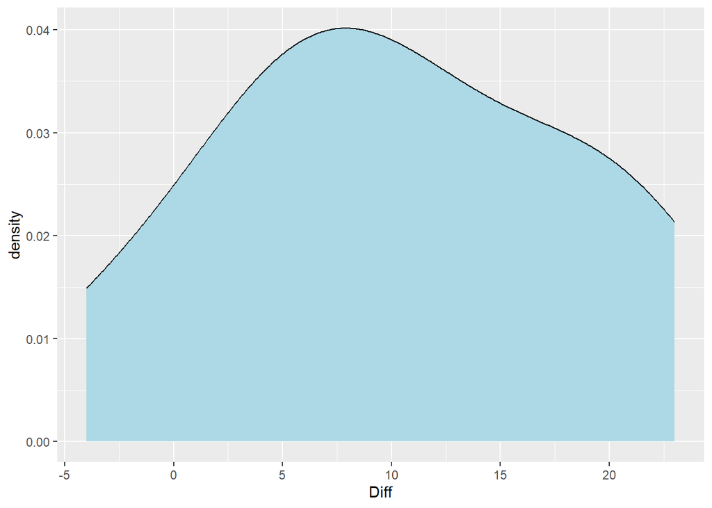

```r
## Test of Normality Density plot of difference data
ggplot(MyData3_wide, aes(x = Diff)) + geom_density(fill = "lightblue")
```

```r
# Shapiro–Wilk normality test
shapiro.test(MyData3_wide$Diff)
```

```
##
##  Shapiro-Wilk normality test
##
## data:  MyData3_wide$Diff
## W = 0.97549, p-value = 0.9366
```

```r
# P-value > alpha so fail to reject H0;

# Paired t-test H1: mu_after - mu_before > 0 H1: mu_diff > 0 t.test will always
# use x-y

t.test(x = MyData3_wide$After, y = MyData3_wide$Before, alternative = "greater",
    paired = T, var.equal = T)
```

```
##
##  Paired t-test
##
## data:  MyData3_wide$After and MyData3_wide$Before
## t = 3.8084, df = 9, p-value = 0.002082
## alternative hypothesis: true mean difference is greater than 0
## 95 percent confidence interval:
##  5.290359      Inf
## sample estimates:
## mean difference
##            10.2
```

```r
t.test(MyData3_wide$After, MyData3_wide$Before, paired = TRUE, alternative = "greater")
```

```
##
##  Paired t-test
##
## data:  MyData3_wide$After and MyData3_wide$Before
## t = 3.8084, df = 9, p-value = 0.002082
## alternative hypothesis: true mean difference is greater than 0
## 95 percent confidence interval:
##  5.290359      Inf
## sample estimates:
## mean difference
##            10.2
```

```r
# conclusion shown that p-value is less than 0.05, so we can reject null
# hypotesis means post-test score better then pre-test score;

### cannot use 'paired' in formula method!! t.test(Score ~ Time, data =
### MyData3, mu = 0, paired = T, alternative = 'greater') cannot use 'paired'
### in formula method!!


# Alternatively, use Diff in MyData3_wide H0 == 5, H1 > 5

t.test(MyData3_wide$Diff, mu = 5, alternative = "greater", var.equal = T)
```

```
##
##  One Sample t-test
##
## data:  MyData3_wide$Diff
## t = 1.9415, df = 9, p-value = 0.04205
## alternative hypothesis: true mean is greater than 5
## 95 percent confidence interval:
##  5.290359      Inf
## sample estimates:
## mean of x
##      10.2
```

```r
# ต้องมีmu = 0 มาด้วย semiliar to 1-t-test;

# Conclusion
```

## ==== **One-way ANOVA** ====

มีมากกว่า 2 group

A one-way analysis of variance (ANOVA) is similar to an independent *t*-test, except that it is capable of comparing more than two groups.

We will conduct the ANOVA by constructing a general linear model with the `lm` function in the native `stats` package. The general linear model is the basis for more advanced parametric models that can include multiple independent variables that can be continuous or factor variables.

**Appropriate data**

- One-way data. That is, one measurement variable in two or more groups.
- Dependent variable is **interval/ratio**, and is continuous.
- Independent variable is a factor with two or more levels. That is, two or more groups.
- In the general linear model approach, residuals are normally distributed.
- In the general linear model approach, groups have the same variance. That is, homoscedasticity or homogeneity of variances.
- Observations among groups are independent. That is, not paired or repeated measures data.
- Moderate deviation from normally-distributed residuals is permissible.

**Hypotheses**

- Null hypothesis: The means of the measurement variable for each group are equal.
- Alternative hypothesis (two-sided): The means of the measurement variable for among groups are not equal.

**Interpretation**

- Reporting significant results for the omnibus test as “Significant differences were found among means for groups.” is acceptable. Alternatively, “A significant effect for Independent Variable on Dependent Variable was found.”
- Reporting significant results for mean separation post-hoc tests as “Mean of variable Y for group A was different than that for group B.” is acceptable.

### **One-way ANOVA example**

In the following example, Brendon Small, Coach McGuirk, and Melissa Robbins have their students keep diaries of what they eat for a week, and then calculate the daily sodium intake in milligrams. Since the classes have received different nutrition education programs, they want to see if the mean sodium intake is the same among classes.

Plots will be used to check model assumptions for normality of residuals and homoscedasticity.

Finally, if the effect of *Instructor* is significant, a mean comparison test will be conducted to determine which group means differ from which others.

#### **Conduct analysis of variance**

The table of results contains the *p*-value for each effect tested in the model.

```r
MyData4 <- read_xlsx("./Data/parametric_data.xlsx", sheet = "Sheet4")
class(MyData4)
```

```
## [1] "tbl_df"     "tbl"        "data.frame"
```

```r
# Order factors by the order in data frame. Otherwise, R will alphabetize them

# why we need to change it to factor ????
# เพราะ One-way ANOVA ต้องการให้ตัวแปรอิสระเป็น “ตัวแปรกลุ่ม (categorical)”
# ใน R ตัวแปรกลุ่ม = factor
# ถ้าไม่แปลงเป็น factor → R อาจตีความผิดว่าเป็นตัวเลขต่อเนื่อง 😱

MyData4$Instructor = factor(MyData4$Instructor,
                         levels = unique(MyData4$Instructor))
MyData4$Instructor = as.factor(MyData4$Instructor)
class(MyData4$Instructor);
```

```
## [1] "factor"
```

```r
MyData4 |>
  group_by(Instructor) |>
  summarise(
    mean_sodium = mean(Sodium),
    sd_sodium = sd(Sodium),
  )
```

```
## # A tibble: 3 × 3
##   Instructor     mean_sodium sd_sodium
##   <fct>                <dbl>     <dbl>
## 1 Brendon Small        1288.      194.
## 2 Coach McGuirk        1246.      142.
## 3 Melissa Robins       1124.      143.
```

```r
# Summarize data by group
library(FSA)
Summarize(Sodium ~ Instructor,
          data = MyData4,
          digits = 3)
```

```
##       Instructor  n    mean      sd  min      Q1 median      Q3  max
## 1  Brendon Small 20 1287.50 193.734  950 1150.00 1300.0 1400.00 1700
## 2  Coach McGuirk 20 1246.25 142.412 1000 1143.75 1212.5 1350.00 1525
## 3 Melissa Robins 20 1123.75 143.149  900 1006.25 1112.5 1231.25 1400
```

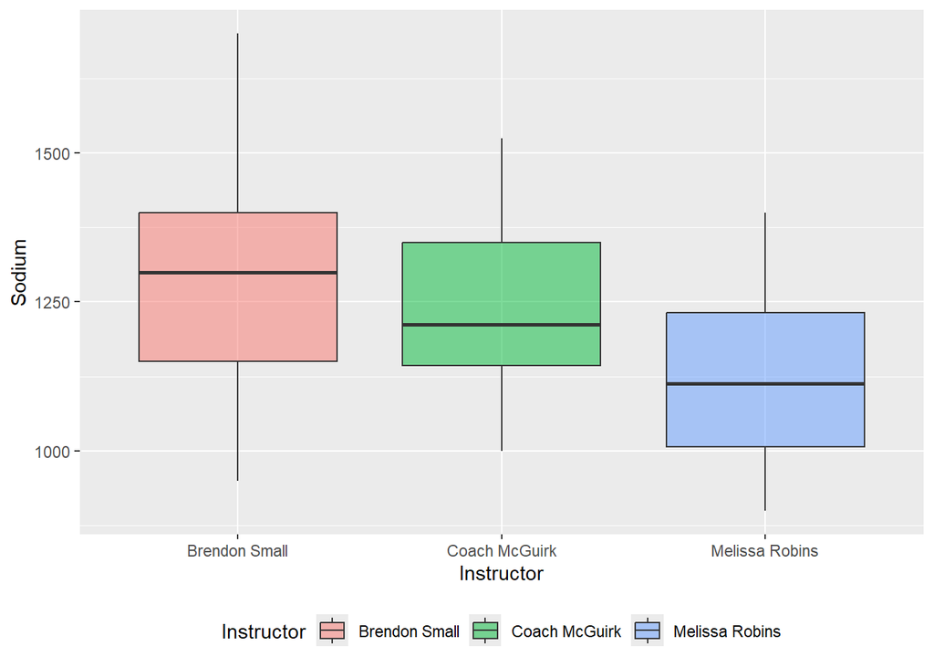

```r
# Box plots for data by group
ggplot(MyData4, aes(y = Sodium, x = Instructor, fill = Instructor)) +
    geom_boxplot(alpha = 0.5) +
    theme(legend.position = "bottom")
```

```r
# confident inteval mu += (t_alpha/2)*(SD/sqrt(n));
# Plot of means and confidence intervals

library(rcompanion)
Mean_conf <- groupwiseMean(Sodium ~ Instructor, data = MyData4,
                           conf = 0.95, digits = 3)
Mean_conf
```

```
##       Instructor  n Mean Conf.level Trad.lower Trad.upper
## 1  Brendon Small 20 1290       0.95       1200       1380
## 2  Coach McGuirk 20 1250       0.95       1180       1310
## 3 Melissa Robins 20 1120       0.95       1060       1190
```

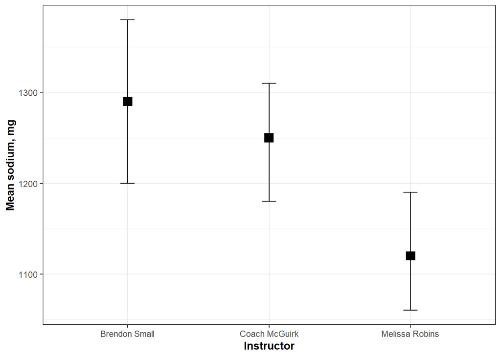

```r
ggplot(Mean_conf,aes(x = Instructor,y = Mean)) +
geom_errorbar(aes(ymin = Trad.lower, ymax = Trad.upper), width = 0.1, size  = 0.5)+
geom_point(shape = 15, size  = 4) + #point of mean
theme_bw() +
theme(axis.title = element_text(face = "bold")) +
ylab("Mean sodium, mg")
```

```r
# Define linear model

# Check Histogram of residuals


# Conduct analysis of variance
# H0: mu_A = mu_B = mu_C
# H1: at least 1 group has different mean
# H1: mu_A != mu_B != mu_C (WRONG!!!)

# Another method (run ANOVA directly)
result_anova <- aov(Sodium ~ Instructor, data = MyData4)
summary(result_anova)
```

```
##             Df  Sum Sq Mean Sq F value  Pr(>F)
## Instructor   2  290146  145073   5.558 0.00624 **
## Residuals   57 1487812   26102
## ---
## Signif. codes:  0 '***' 0.001 '**' 0.01 '*' 0.05 '.' 0.1 ' ' 1
```

```r
# Post-hoc analysis
# Tukey multiple pairwise-comparisons
# Tukey HSD (Tukey Honest Significant Differences)
TukeyHSD(result_anova);
```

```
##   Tukey multiple comparisons of means
##     95% family-wise confidence level
##
## Fit: aov(formula = Sodium ~ Instructor, data = MyData4)
##
## $Instructor
##                                 diff       lwr         upr     p adj
## Coach McGuirk-Brendon Small   -41.25 -164.1941  81.6941219 0.7000083
## Melissa Robins-Brendon Small -163.75 -286.6941 -40.8058781 0.0061739
## Melissa Robins-Coach McGuirk -122.50 -245.4441   0.4441219 0.0510271
```

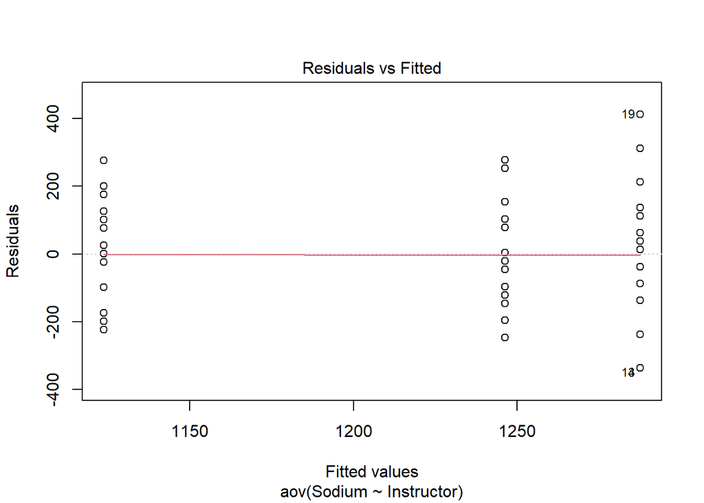

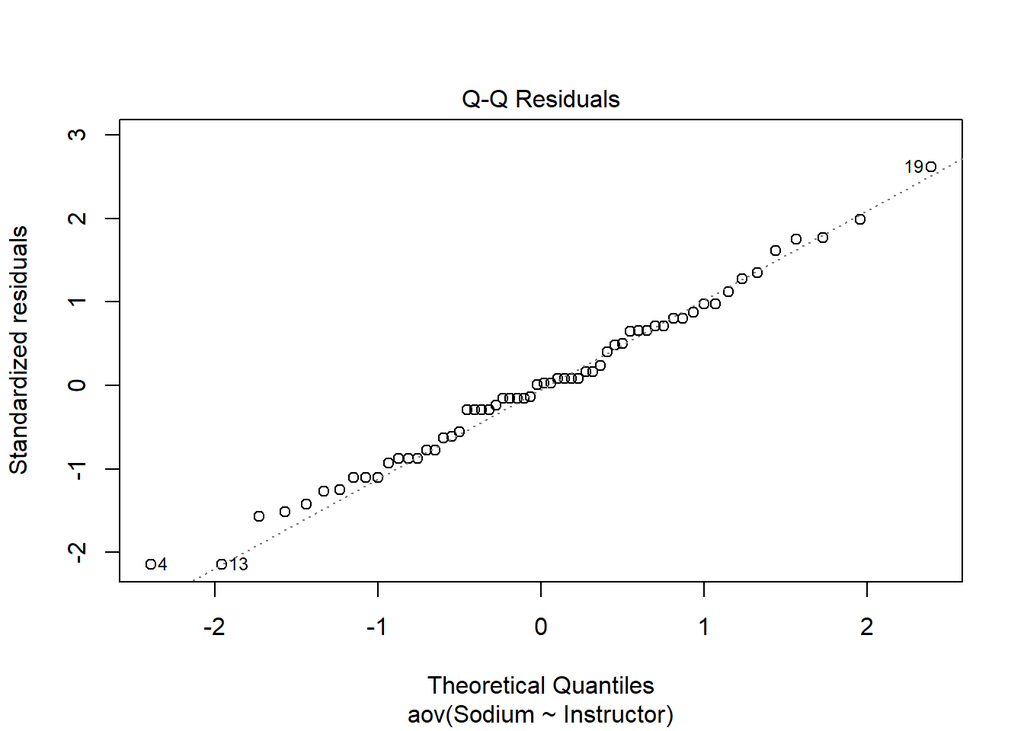

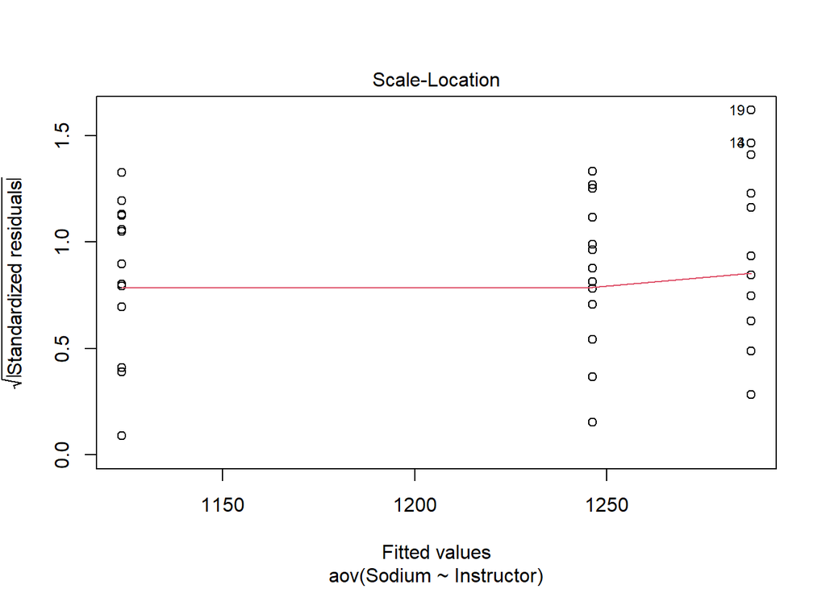

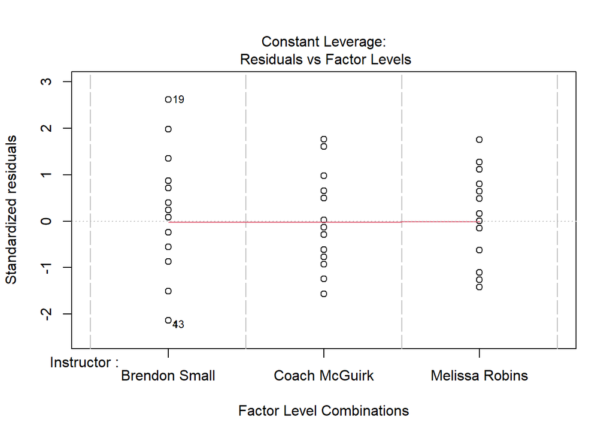

```r
# Post Analysis
# 1. Any pattern between Residual and Fitted value?
# 2. Residual is normally distributed or not?
plot(result_anova)
```

## ==== **Two-way ANOVA** ====

A two-way anova can investigate the *main effects* of each of two independent factor variables, as well as the effect of the *interaction* of these variables.

**Appropriate data**

- Two-way data. That is, one dependent variable measured across two independent factor variables.
- Dependent variable is **interval/ratio**, and is continuous.
- Independent variables are a factor with two or more levels. That is, two or more groups for each independent variable.
- In the general linear model approach, residuals are normally distributed
- In the general linear model approach, groups have the same variance. That is, homoscedasticity.
- Observations among groups are independent. That is, not paired or repeated measures data.
- Moderate deviation from normally-distributed residuals is permissible.

**Hypotheses**

- Null hypothesis 1: The means of the dependent variable for each group in the first independent variable are equal.
- Alternative hypothesis 1 (two-sided): The means of the dependent variable for each group in the first independent variable are not equal.
- Similar hypotheses are considered for the other independent variable.
- Similar hypotheses are considered for the interaction effect.

**Interpretation**

- Reporting significant results for the effect of one independent variable as “Significant differences were found among means for groups.” is acceptable. Alternatively, “A significant effect for independent variable on dependent variable was found.”
- Reporting significant results for the interaction effect as “A significant effect for the interaction of independent variable 1 and independent variable 2 on dependent variable was found.” Is acceptable.
- Reporting significant results for mean separation post-hoc tests as “Mean of variable Y for group A was different than that for group B.” is acceptable.

### **Two-way ANOVA example**

This example will revisit the sodium intake data set with Brendon Small and the other instructors. This time, though, they want to test not only the different nutrition education programs (indicated by *Instructor*), but also four supplements to the program, each of which they have used with some students.

```r
MyData5 <- read_xlsx("./Data/parametric_data.xlsx", sheet = "Sheet5")

MyData5$Instructor = factor(MyData5$Instructor,
                            levels=unique(MyData5$Instructor))

MyData5$Supplement = factor(MyData5$Supplement,
                            levels=unique(MyData5$Supplement))

# Use Summarize to check if cell sizes are balanced
# We can use the n or nvalid columns in the Summarize output to check if cell sizes are balanced (if each combination of treatments have the same number of observations).

library(rcompanion)
Mean_conf2 <- groupwiseMean(Sodium ~ Instructor, data = MyData5,
                           conf = 0.95, digits = 3)
Mean_conf2
```

```
##       Instructor  n Mean Conf.level Trad.lower Trad.upper
## 1  Brendon Small 20 1290       0.95       1200       1380
## 2  Coach McGuirk 20 1250       0.95       1180       1310
## 3 Melissa Robins 20 1120       0.95       1060       1190
```

```r
Mean_conf3 <- groupwiseMean(Sodium ~ Supplement, data = MyData5,
                           conf = 0.95, digits = 3)
Mean_conf3
```

```
##   Supplement  n Mean Conf.level Trad.lower Trad.upper
## 1          A 15 1150       0.95       1070       1240
## 2          B 15 1310       0.95       1250       1370
## 3          C 15 1150       0.95       1050       1250
## 4          D 15 1260       0.95       1160       1370
```

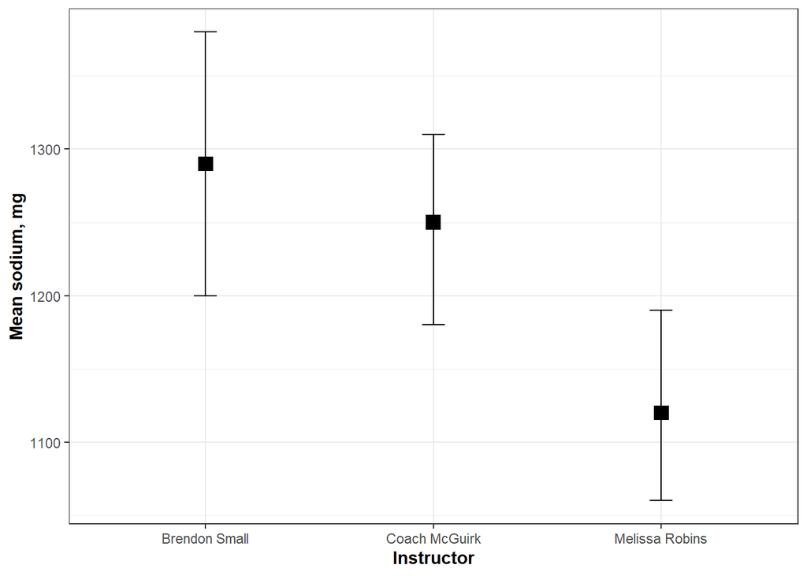

```r
ggplot(Mean_conf2,aes(x = Instructor,y = Mean)) +
geom_errorbar(aes(ymin = Trad.lower, ymax = Trad.upper), width = 0.1, size  = 0.5)+
geom_point(shape = 15, size  = 4) + #point of mean
theme_bw() +
theme(axis.title = element_text(face = "bold")) +
ylab("Mean sodium, mg")
```

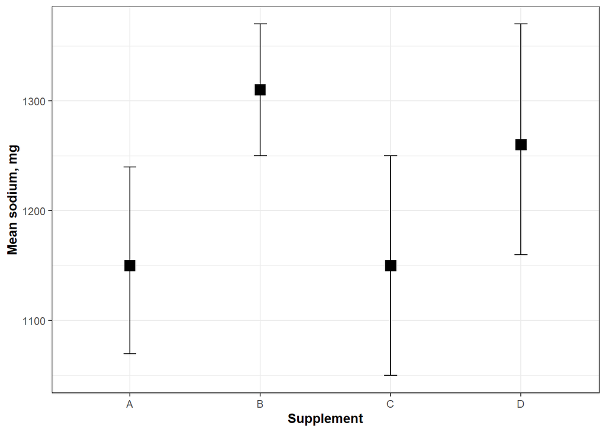

```r
ggplot(Mean_conf3,aes(x = Supplement,y = Mean)) +
geom_errorbar(aes(ymin = Trad.lower, ymax = Trad.upper), width = 0.1, size  = 0.5)+
geom_point(shape = 15, size  = 4) + #point of mean
theme_bw() +
theme(axis.title = element_text(face = "bold")) +
ylab("Mean sodium, mg")
```

```r
library(FSA)
Summarize(Sodium ~ Supplement + Instructor,
          data = MyData5,
          digits = 3)
```

```
##    Supplement     Instructor n mean      sd  min   Q1 median   Q3  max
## 1           A  Brendon Small 5 1260 191.703  950 1200   1350 1400 1400
## 2           B  Brendon Small 5 1340 132.994 1150 1300   1325 1425 1500
## 3           C  Brendon Small 5 1220 238.747  950 1150   1150 1250 1600
## 4           D  Brendon Small 5 1330 233.452 1050 1300   1300 1300 1700
## 5           A  Coach McGuirk 5 1160  82.158 1050 1100   1200 1200 1250
## 6           B  Coach McGuirk 5 1360 100.933 1250 1325   1350 1350 1525
## 7           C  Coach McGuirk 5 1175 148.955 1000 1125   1125 1225 1400
## 8           D  Coach McGuirk 5 1290 151.658 1150 1200   1200 1400 1500
## 9           A Melissa Robins 5 1040 108.397  900  950   1100 1100 1150
## 10          B Melissa Robins 5 1240  62.750 1150 1225   1250 1250 1325
## 11          C Melissa Robins 5 1045 116.458  925  950   1025 1125 1200
## 12          D Melissa Robins 5 1170 178.885  950 1100   1100 1300 1400
```

```r
# Define linear model
# Note that the interaction of Instruction and Supplement is indicated in the model definition by Instructor:Supplement.


# Histogram of residuals


# Conduct analysis of variance
result_anova2 <- aov(Sodium ~ Instructor + Supplement, data = MyData5)
summary(result_anova2)
```

```
##             Df  Sum Sq Mean Sq F value  Pr(>F)
## Instructor   2  290146  145073   6.629 0.00266 **
## Supplement   3  306125  102042   4.663 0.00571 **
## Residuals   54 1181687   21883
## ---
## Signif. codes:  0 '***' 0.001 '**' 0.01 '*' 0.05 '.' 0.1 ' ' 1
```

```r
result_anova3 <- aov(Sodium ~ Instructor , data = MyData5)
summary(result_anova2)
```

```
##             Df  Sum Sq Mean Sq F value  Pr(>F)
## Instructor   2  290146  145073   6.629 0.00266 **
## Supplement   3  306125  102042   4.663 0.00571 **
## Residuals   54 1181687   21883
## ---
## Signif. codes:  0 '***' 0.001 '**' 0.01 '*' 0.05 '.' 0.1 ' ' 1
```

```r
# Another method (run ANOVA directly)


# Tukey multiple pairwise-comparisons
# Tukey HSD (Tukey Honest Significant Differences
TukeyHSD(result_anova2)
```

```
##   Tukey multiple comparisons of means
##     95% family-wise confidence level
##
## Fit: aov(formula = Sodium ~ Instructor + Supplement, data = MyData5)
##
## $Instructor
##                                 diff       lwr        upr     p adj
## Coach McGuirk-Brendon Small   -41.25 -153.9875  71.487548 0.6540131
## Melissa Robins-Brendon Small -163.75 -276.4875 -51.012452 0.0026628
## Melissa Robins-Coach McGuirk -122.50 -235.2375  -9.762452 0.0302520
##
## $Supplement
##            diff        lwr       upr     p adj
## B-A  160.000000   16.80986 303.19014 0.0228178
## C-A   -6.666667 -149.85681 136.52348 0.9993195
## D-A  110.000000  -33.19014 253.19014 0.1875713
## C-B -166.666667 -309.85681 -23.47652 0.0164082
## D-B  -50.000000 -193.19014  93.19014 0.7912613
## D-C  116.666667  -26.52348 259.85681 0.1477021
```

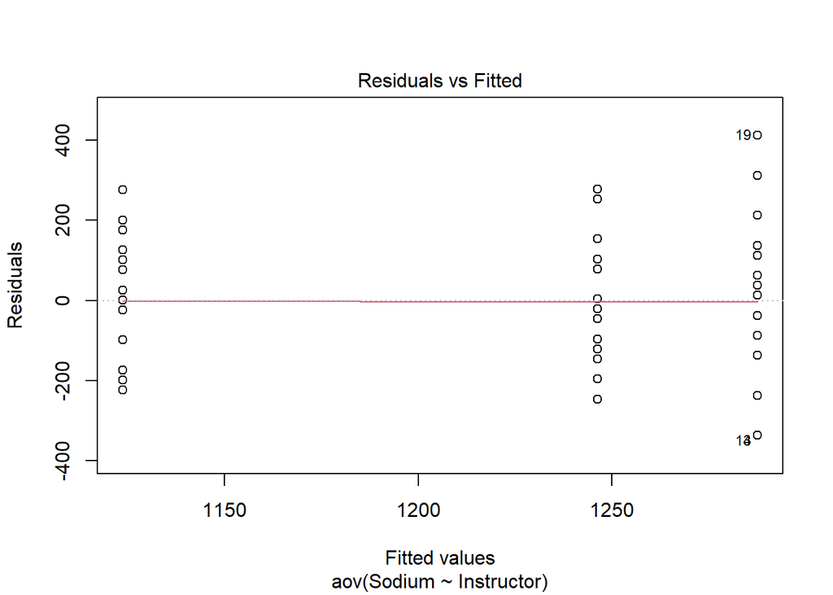

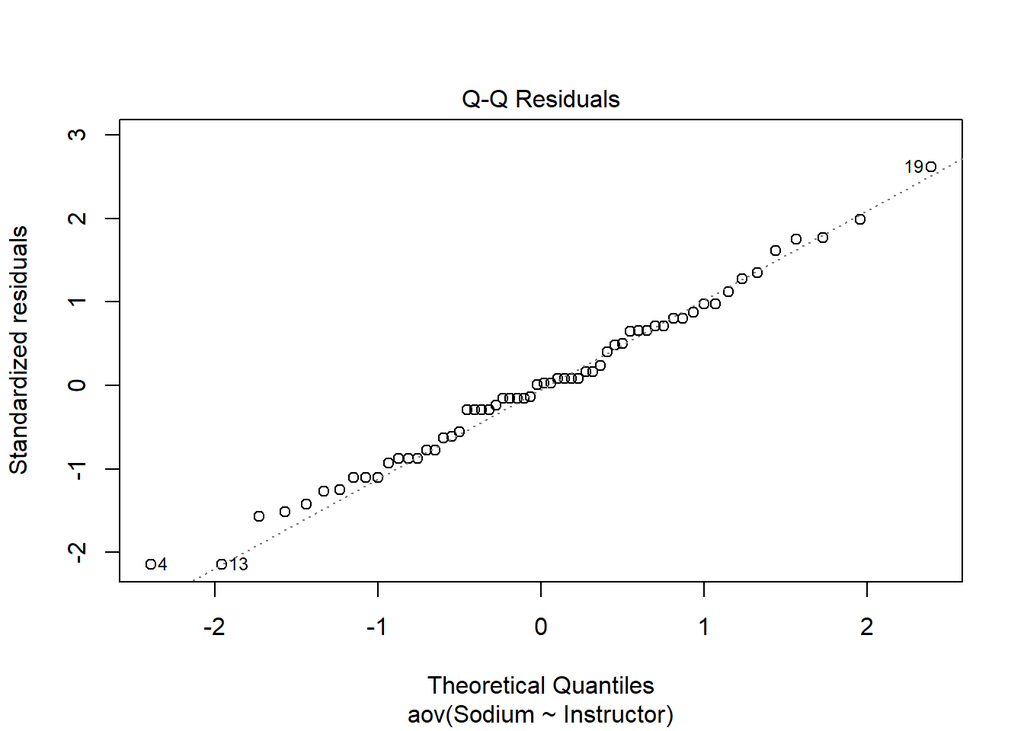

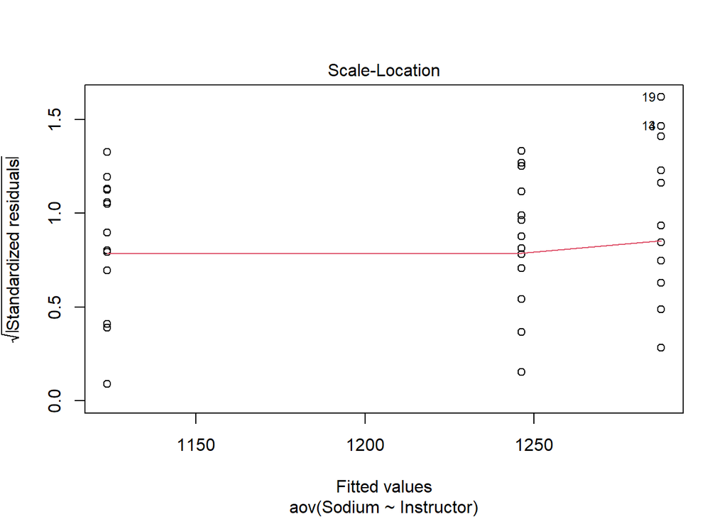

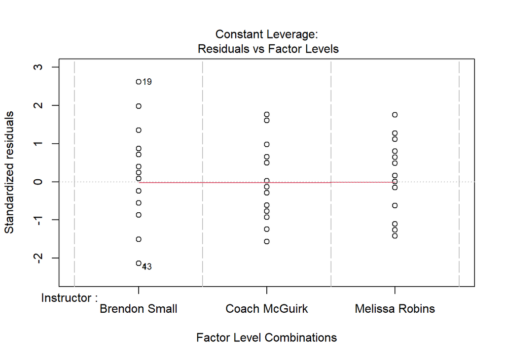

```r
# Post Analysis
# 1. Any pattern between Residual and Fitted value?
# 2. Residual is normally distributed or not?

plot(result_anova3)
```

End-of-File